# Lab 3: Mine Crafting

As with previous labs, be sure to submit only the `lab3.ipynb` and `lab3.html` version of the lab in your github `Lab3` folder. No more, and no less.

## Introduction

Imagine you are a scientist for a mining company that operates a vertical mine at the Earth's equator. This is one of the deepest mines on Earth; it's roughly 4 km to the bottom of the shaft. Your boss proposes to measure the vertical depth of the shaft by dropping a 1 kg test mass and accurately measuring the time to hit the bottom.

You will be guided in your investigations below and submit your report in the form of this notebook. Be sure to be quantitative in nature, produce highly polished plots, with appropriate titles, units, etc.

A table of relevant physical constants is below. Good luck!

| Quantity | Value |
| --- | --- |
| Gravitational Constant ($G$) | $6.6743 \times 10^{-11}$ m$^3$/kg/s$^2$ |
| Gravitational Acceleration ($g_o$) | 9.81 m/s$^2$ (approximate) |
| Mass of the Earth ($M_{\oplus}$) | $5.972 \times 10^{24}$ kg |
| Mass of the Moon ($M_{m}$) | $7.35 \times 10^{22}$ kg |
| Radius of the Earth ($R_{\oplus}$) | 6378.1 km |
| Radius of the Moon ($R_{m}$) | 1738.1 km |
| Earth's Rotation Rate at the Equator | $7.272 \times 10^{-5} $ rad/s |

## Part 1: The Ideal Case

In this section and the following sections, we calculate the time for the 1 kg test mass to reach the bottom of the mineshaft under a series of increasingly complex assumptions. Remember that a projectile experiencing a constant gravitational force, plus a drag force, obeys the following second order differential equation:

$$ \frac{d^2y}{dt^2} = -g + \alpha \left| \frac{dy}{dt} \right|^{\gamma} \tag{1} $$

where $t$ is time, $y$ is the height, $g$ is the gravitational acceleration, $\alpha$ is the drag coefficient, and $\gamma$ is the speed dependence of the drag. For example, for $\gamma=2$, the drag force grows proportionally to the speed *squared*. **Hint**: pay particular attention to the sign conventions in your implementation! The drag, by definition, should *oppose* the direction of motion.

1. First, make a simple calculation of how long a test mass would take to reach the bottom of the 4km shaft assuming no drag. This is the simple free-fall algebraic expression you know from PHYS 171.
2. Next, reduce (1) into a *system* of coupled first order differential equations by setting the velocity $v = dy/dt$.
3. Numerically solve (1) using `solve_ivp` assuming $\alpha=0$. Plot the position and velocity as a function of time.  
   Draw a horizontal dashed line at the depth of the bottom of the shaft, to make it easy to see. Make the plot look nice, including displaying the position on the left axes, and plotting the velocity on a second right axis, using matplotlib `twinx` capability.  
   In your notebook, label this figure clearly as **Figure 1**.
4. Using the `events` detection capability of `solve_ivp`, calculate the time at which the mass hits the bottom of the shaft in the case of zero drag ($\alpha=0$). Compare this to your analytic calculation and discuss any differences you might see.

```python
# constants
G = 6.6743e-11
g0 = 9.81
M_earth = 5.972e24
M_moon = 7.35e22
R_earth = 6378.1e3
R_moon = 1738.1e3
omega_earth = 7.272e-5

import numpy as np
import matplotlib.pyplot as plt
from scipy.integrate import solve_ivp

g = 9.81 #m/s^2
def t(x):  # time it takes as a function of distance
    return np.sqrt((2*x)/g)  # we don't need x_0 and v_0 since we assume 0 for both

print(f"Time it takes to reach the bottom of a 4 km shaft: {t(4000):.4f} s")
# Time it takes to reach bottom of the 4km pit. In terms of acceleration.
```

```
Time it takes to reach the bottom of a 4 km shaft: 28.5569 s
```

we introduce a new variable for the velocity, $v = \frac{dy}{dt}$. This means the second derivative of position is the first derivative of velocity ($\frac{dv}{dt} = \frac{d^2y}{dt^2}$).For the ideal case with no drag ($\alpha = 0$), the equation is simply $\frac{d^2y}{dt^2} = -g_0$. Substituting our velocity variable gives us the coupled system of first-order differential equations:$$\frac{dy}{dt} = v$$$$\frac{dv}{dt} = -g_0$$

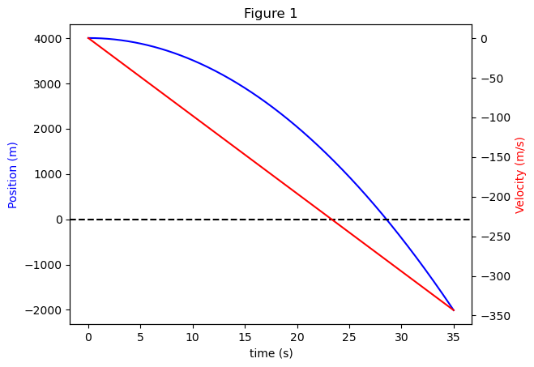

```python
def free_fall(t, Y):
    y, v = Y
    dy_dt = v
    dv_dt = -g0
    return [dy_dt, dv_dt]

def hit_bottom(t, Y):
    return Y[0]

t_span = (0,35)
Y0 = [4000.0, 0.0]
t_eval = np.linspace(0, 35, 500)

sol = solve_ivp(free_fall, t_span, Y0, t_eval=t_eval, events=hit_bottom)

fig1, ax1 = plt.subplots()

ax1.plot(sol.t, sol.y[0], 'b-')
ax1.set_xlabel("time (s)")
ax1.set_ylabel("Position (m)", color='b')
ax1.axhline(0, color='black', linestyle='--')

ax2 = ax1.twinx()
ax2.plot(sol.t, sol.y[1], 'r-')
ax2.set_ylabel("Velocity (m/s)", color='r')

plt.title("Figure 1")
```

```python
t_numerical = sol.t_events[0][0]
print(f"Numerical time to hit bottom: {t_numerical:.4f} s")
```

```
Numerical time to hit bottom: 28.5569 s
```

The numerical solver calculates the time to hit the bottom as approximately 28.56 seconds. This matches the analytical calculation exactly. Because there is no drag and $g$ is perfectly constant, the numerical Runge-Kutta method is pretty much perfect!

## Part 2: Including Drag and a Variable g

In practice, we cannot ignore drag, and we should also not assume that $g$ is a constant. If you approximate that the mass of the Earth is distributed homogenously (which it is not!), then the gravitational constant $g$ will depend on your distance $r$ from the center of the Earth in a simple linear way:

$$ g(r) = g_o \left( \frac{r}{R_{\oplus}} \right) \tag{2} $$

where $g_o$ is the gravity at the surface, and $R_{\oplus}$ is the radius of the Earth.

1. Make a new plot that shows the velocity and position as a function of  
   time assuming $g(y)$. Be careful with coordinate systems! The test mass' position should be at the Earth radius at $t=0$, and falling down. But for plotting purposes, it will be useful to plot the height above the bottom of the shaft.  
   In your notebook, label this figure clearly as **Figure 2**.
2. What effect does incorporating a height-dependent $g$ have on the fall time? Explain.
3. Now, turn on drag, and replot the position and velocity. For most things, $\gamma=2$ is a good assumption. How can you calibrate the value of $\alpha$? Think about what we did in Lecture 15/16, where we assumed a sky-diver's terminal speed was 50 m/s. You should assume the same of the test mass. What affect does including drag have on the fall time?

```
Time to hit bottom (var g, no drag): 28.5584 s
```

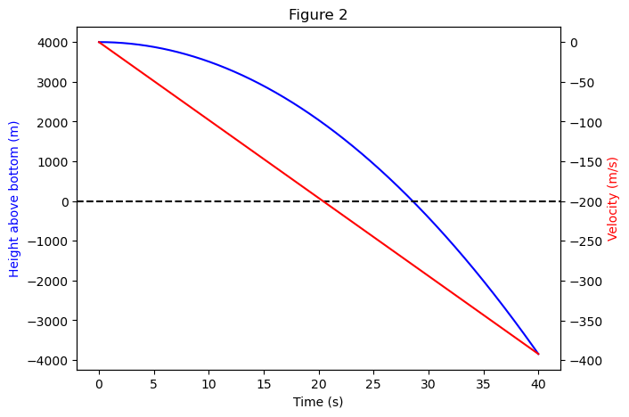

```python
# Q1
r_bottom = R_earth - 4000.0

def var_g_fall(t, Y):
    r, v = Y
    dr_dt = v
    dv_dt = -g0 * (r / R_earth)
    return [dr_dt, dv_dt]

def hit_bottom(t, Y):
    return Y[0] - r_bottom

t_span_ideal = (0, 40)
Y0 = [R_earth, 0.0]
t_eval_ideal = np.linspace(0, 40, 1000)

sol_ideal = solve_ivp(var_g_fall, t_span_ideal, Y0, t_eval=t_eval_ideal, events=hit_bottom)

fig2, ax1 = plt.subplots(figsize=(7,5))
ax1.plot(sol_ideal.t, sol_ideal.y[0] - r_bottom, 'b-')
ax1.set_xlabel("Time (s)")
ax1.set_ylabel("Height above bottom (m)", color='b')
ax1.axhline(0, color='black', linestyle='--')

ax2 = ax1.twinx()
ax2.plot(sol_ideal.t, sol_ideal.y[1], 'r-')
ax2.set_ylabel("Velocity (m/s)", color='r')
plt.title("Figure 2")

print(f"Time to hit bottom (var g, no drag): {sol_ideal.t_events[0][0]:.4f} s")
```

```
Time to hit bottom (var g, WITH drag): 83.5431 s
```

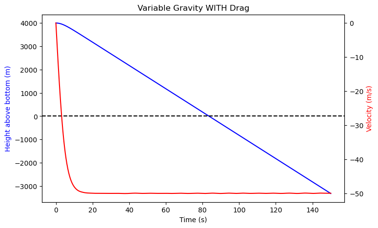

```python
# Q3
v_term = 50.0
alpha = g0 / (v_term**2)

def drag_fall(t, Y):
    r, v = Y
    dr_dt = v
    dv_dt = -g0 * (r / R_earth) + alpha * (v**2)
    return [dr_dt, dv_dt]

t_span_drag = (0, 150)
t_eval_drag = np.linspace(0, 150, 1000)

sol_drag = solve_ivp(drag_fall, t_span_drag, Y0, t_eval=t_eval_drag, events=hit_bottom)

fig, ax3 = plt.subplots(figsize=(8, 5))
ax3.plot(sol_drag.t, sol_drag.y[0] - r_bottom, 'b-')
ax3.set_xlabel("Time (s)")
ax3.set_ylabel("Height above bottom (m)", color='b')
ax3.axhline(0, color='black', linestyle='--')

ax4 = ax3.twinx()
ax4.plot(sol_drag.t, sol_drag.y[1], 'r-')
ax4.set_ylabel("Velocity (m/s)", color='r')
plt.title("Variable Gravity WITH Drag")

print(f"Time to hit bottom (var g, WITH drag): {sol_drag.t_events[0][0]:.4f} s")
```

## Part 3: The Coriolis Force

Since the Earth is rotating, there is a Coriolis force on the test mass as it falls. The force can be quite large. For example, imagine the mine shaft is on the Earth's equator and pointed towards the Earth's center. The equator rotates at about half a kilometer per second. So once the test mass has fallen for some time, it will bump into the wall, unless the shaft is very wide. The Coriolis force $\vec{F_c}$ is:

$$ \vec{F_c} = -2m \, \left( \vec{\Omega} \times \vec{v} \right) \tag{3} $$

where $\vec{\Omega}$ is the Earth's rotation rate for a vector along $\hat{z}$ and $m$ is the mass of the object (1 kg for the test mass in this case). For a mine shaft on the equator, we might pick a right-handed coordinate system with the $\hat{x}$ axis along the East, $\hat{y}$ down into the mine shaft, and $\hat{z}$ along the North. This implies the component of the force are:

\begin{equation} F_{c_x} = + 2m \, \Omega v_y \tag{4} \end{equation} \begin{equation} F_{c_y} = - 2m \, \Omega v_x \tag{5} \end{equation} \begin{equation} F_{c_z} = 0 \tag{6} \end{equation}

1. Extend and update your differential equations of motion to include the Coriolis force. You will need to add a Coriolis acceleration term to your equation for the depth coordinate (remember, $F=ma$), and additionally, start tracking the velocity and position in the transverse direction (``side-to-side'' in the shaft).
2. Plot the transverse position of the object as a function of depth, initially assuming $\alpha=0$. That is, both axes will have units of distance. Plot ``dots" every few seconds so that you can see how the particle moves over time. Note that your depth and transverse axes are likely to have very different length scales. The depth will have a range of 4 km, while the transverse direction is about 5m.  
   In your report, this should be **Figure 3**.
3. If the mine shaft is 5m wide, and you drop the test mass from the center, does the test mass reach the bottom? Or does it bump into the wall first?
4. Now turn drag back on. Does drag make any difference here?

```python
# Q1
def cor_fall(t, Y):
    x, y, vx, vy = Y
    Fcx = 2*omega_earth*vy
    Fcy = -2*omega_earth*vx
    dx_dt = vx
    dvx_dt = Fcx
    dy_dt = vy
    dvy_dt = g0 * ((R_earth-y) / R_earth) + Fcy
    return [dx_dt, dy_dt, dvx_dt, dvy_dt]
```

```
Final transverse deflection (NO drag): 5.5383 m
```

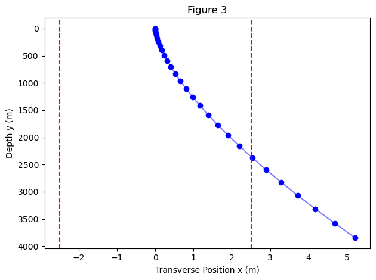

```python
# Q2
def hit_bottom(t, Y):
    return Y[1] - 4000.0

hit_bottom.terminal = True # important to stop the solver at 4000m (bottom)

t_span_cor = (0,35)
Y0 = [0.0, 0.0, 0.0, 0.0]
t_evals_cor = np.linspace(0,35,36)

sol_cor_nodrag = solve_ivp(cor_fall, t_span, Y0, t_eval=t_evals_cor, events=hit_bottom)

fig3, ax = plt.subplots()
ax.plot(sol_cor_nodrag.y[0], sol_cor_nodrag.y[1], 'bo')
ax.plot(sol_cor_nodrag.y[0], sol_cor_nodrag.y[1], 'b-', alpha=0.5)
ax.set_xlabel("Transverse Position x (m)")
ax.set_ylabel("Depth y (m)")
ax.set_title("Figure 3")
ax.invert_yaxis()
ax.axvline(-2.5, color='r', linestyle='--') # mineshaft walls
ax.axvline(2.5, color='r', linestyle='--')

print(f"Final transverse deflection (NO drag): {sol_cor_nodrag.y_events[0][0][0]:.4f} m")

plt.tight_layout()
```

```python
v_term = 50.0
alpha = g0 / (v_term**2)

def cor_drag(t, Y):
    x, y, vx, vy = Y
    dx_dt = vx
    dy_dt = vy
    speed = np.sqrt(vx**2 + vy**2)
    dvx_dt = 2 * omega_earth * vy - alpha * speed * vx
    dvy_dt = g0 * ((R_earth - y) / R_earth) - 2 * omega_earth * vx - alpha * speed * vy
    return [dx_dt, dy_dt, dvx_dt, dvy_dt]

t_span_drag = (0, 150)
t_eval_drag = np.linspace(0, 150, 151)

sol_cor_drag = solve_ivp(cor_drag, t_span_drag, Y0, t_eval=t_eval_drag, events=hit_bottom)

print(f"Final transverse deflection (WITH drag): {sol_cor_drag.y_events[0][0][0]:.4f} m")
```

```
Final transverse deflection (WITH drag): 2.7995 m
```

Q3: No, it bumps into the wall! Based on the simulation without drag, the test mass deflects to the east by approximately 5.54 meters by the time it reaches a depth of 4000m. Because the mine shaft is 5m wide (providing only 2.5m of clearance from the center), the mass easily hits the eastern wall before reaching the bottom.

Q4: Yes, drag makes a massive difference, but counter-intuitively, it reduces the horizontal drift! With drag, the deflection drops to roughly 2.80 meters. Even though the mass takes much longer to fall (giving the Coriolis force more time to act), the drag force is proportional to the total speed squared ($\alpha |\vec{v}| v_x$). Because the vertical velocity ($v_y$) is so high, it creates an immense amount of "cross-wind" air resistance that severely dampens the side-to-side motion. However, at 2.80 meters, it still narrowly bumps into the eastern wall!

## Part 4: An infinitely deep mine

Now, let us consider the theoretical case of an infinitely deep mine -- that is, a tunnel which traverses the full diameter of the Earth. For convenience, imagine the tunnel goes from pole-to-pole, such that $\vec{\Omega} \times \vec{v} = 0$, and the Coriolis force can be neglected, as well as the drag force.

Additionally, continue assuming a constant density Earth.

1. Again, plot the depth and velocity as a function of time. (Be careful with the meaning of $y$, as the particle can theoretically traverse fully through to the other side of the Earth.) Comment on what you see in the graph.  
   In your notebook, label this figure clearly as **Figure 4**.
2. How long will it take for the object to reach the other side? At what time does the object reach the center of the Earth, and at what speed?
3. How does this ``crossing-time" compare to the orbital period, where you assume the object is on a circular orbit, in centripetal balance with the attractive force of the gravity. \begin{equation} \frac{v^2}{R} = \frac{GM}{R^2} \tag{7} \end{equation} gives the orbital speed $v$ for a given Earth radius $R$ and Earth mass $M$.

```
Q2:
Time to reach center: 1266.47 s
Speed at center: 7910.76 m/s
Time to reach other side: 2532.61 s
```

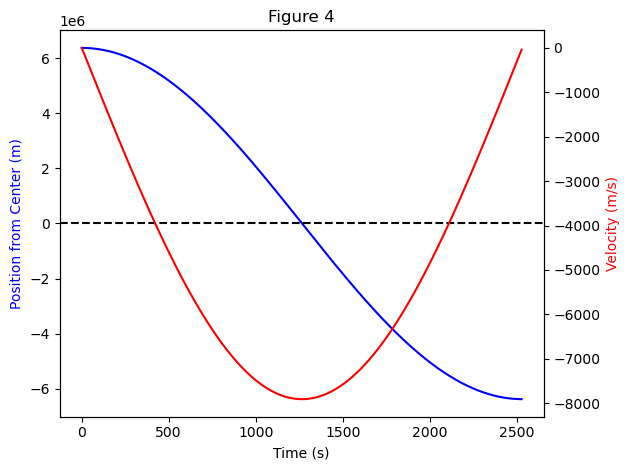

```python
def infinite_fall(t,Y):
    y, v = Y
    dy_dt = v
    dv_dt = -g0 * (y / R_earth)
    return [dy_dt, dv_dt]

def reach_center(t,Y):
    return Y[0]

def reach_other_side(t,Y):
    return Y[1]

reach_other_side.terminal = True
reach_other_side.direction = 1  # only trigger when going from negative to positive velocity (at other side of earth)

t_span = (0,6000)
Y0 = [R_earth, 0.0]
t_eval = np.linspace(0, 6000, 1000)

sol_inf = solve_ivp(infinite_fall, t_span, Y0, t_eval=t_eval,
                    events=[reach_center, reach_other_side])

fig4, ax1 = plt.subplots()
ax1.plot(sol_inf.t, sol_inf.y[0], 'b-')
ax1.set_xlabel("Time (s)")
ax1.set_ylabel("Position from Center (m)", color='b')
ax1.axhline(0, color='black', linestyle='--')

ax2 = ax1.twinx()
ax2.plot(sol_inf.t, sol_inf.y[1], 'r-')
ax2.set_ylabel("Velocity (m/s)", color='r')
ax2.set_title("Figure 4")

t_center = sol_inf.t_events[0][0]
v_center = sol_inf.y_events[0][0][1]
t_other_side = sol_inf.t_events[1][0]

print("Q2:")
print(f"Time to reach center: {t_center:.2f} s")
print(f"Speed at center: {abs(v_center):.2f} m/s")
print(f"Time to reach other side: {t_other_side:.2f} s")

plt.tight_layout()
```

Q1: The graph reveals perfect simple harmonic motion. The position and velocity curves are perfect sine and cosine waves. As the mass falls towards the center, it accelerates, reaching its maximum velocity exactly at the center. It then shoots past the center, and gravity begins pulling it backward, slowing it down until it perfectly stops at the opposite surface ($y = -R_{\oplus}$), before falling back again.

Q3: The theoretical orbital speed for a satellite skimming the surface of the Earth is $v = \sqrt{GM/R_{\oplus}} = \sqrt{g_0 R_{\oplus}}$. This calculates to $\approx$ 7,910 m/s—the identical maximum speed our mass reaches at the Earth's center! We can also check the orbital period $\Rightarrow$ $T = 2\pi\sqrt{R_{\oplus}/g_0}$ (about 84.4 minutes). The "crossing time" to fall entirely through the Earth (~42.2 minutes) is exactly half of the orbital period. Both motions are governed by the exact same natural frequency of the Earth's gravitational well.

## Part 5: A non-uniform Earth

Finally, let us consider the case of a non-uniform Earth, and continue assuming we have no drag. We know from geology that the density increases towards the center. It rises from about 2-3 g/cm$^3$ near the surface, to more like 13 near the center. A simple model for the density $\rho$ as a function of distance from the center of the Earth $r$ is:

$$ \rho(r) = \rho_n \left( 1 - \frac{r^2}{R_{\oplus}^2} \right)^n \tag{8} $$

where $n$ is some exponent, and $\rho_n$ is a normalizing constant. The case of $n=0$ is the constant density Earth, while $n=2$ is closer to the real value. Note that the total mass of the Earth, $M$, must be conserved. Since the mass is the volume integral over the density:

\begin{equation} M = \int_V \rho(r) dV = \int_0^{2\pi} \int_0^{\pi} \int_0^{R_{\oplus}} \rho(r) r^2 \sin \phi \, dr \, d\phi \,d\theta = 4 \pi \int_0^{R_{\oplus}} \rho(r) r^2 \, dr \tag{9} \end{equation}

you will need to recompute the density constant $\rho_n$ for each case of $n>0$, You can use the `quad` integrator for this. Note that the analytic solution is straightforward to do by hand for $n=0$, and still manageable for $n=1,2$. You might consider doing that integral to make sure your method is right, and then you can be confident for $n>0$.

1. Plot the normalized density profile (that is, set $\rho_n=1$) as a function of radius for $n=0, 1, 2, 9$.  
   Put them all on the same plot, with a clear legend.  
   In your notebook, label this figure clearly as **Figure 5**.
2. Now, plot the force profile as a function of radius for $n=0, 1, 2, 9$.  
   This step will show you if your normalization factor $\rho_n$ is correct, because the surface force must be the same for all $n$.  
   In your notebook, label this figure clearly as **Figure 6**.
3. Then, plot the position and velocity as a function of time for $n=0, 1, 2, 9$ as you did in Figure 1/2.  
   In your notebook, label this figure clearly as **Figure 7**.
4. For $n=0, 1, 2, 9$, compute the time to reach the center, and the speed achieved there.

### Part 5, Section A (Density)

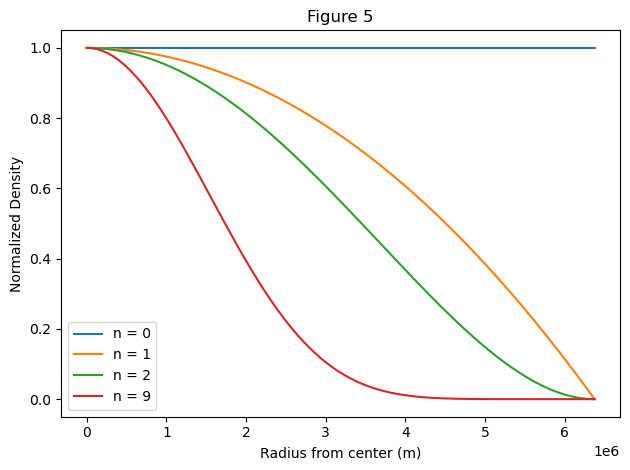

```python
r_array = np.linspace(0, R_earth, 200)
n_values = [0,1,2,9]
fig5, ax = plt.subplots()

for n in n_values:
    # normalized rho
    rho_norm = (1 - (r_array / R_earth)**2)**n
    ax.plot(r_array, rho_norm, label=f'n = {n}')

ax.set_xlabel("Radius from center (m)")
ax.set_ylabel("Normalized Density")
ax.set_title("Figure 5")
ax.legend();
plt.tight_layout()
```

### Part 5, Section B (Forces)

```
Calculated Central Densities (rho_n):
n=0: 5494.87 kg/m^3
n=1: 13737.17 kg/m^3
n=2: 24040.04 kg/m^3
n=9: 135545.12 kg/m^3
```

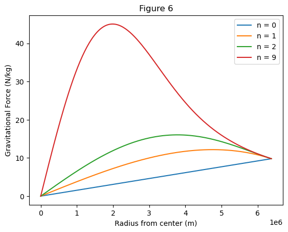

```python
from scipy.integrate import quad

fig6, ax = plt.subplots()

rho_n_dict = {} # save constants for part c

def mass_integrand(r, n):
    return 4 * np.pi * (r**2) * ((1 - (r / R_earth)**2)**n)

for n in n_values:
    total_unnorm_mass, error = quad(mass_integrand, 0, R_earth, args=(n,))
    rho_n = M_earth / total_unnorm_mass
    rho_n_dict[n] = rho_n

    force_array = np.zeros(len(r_array))  # force at every step
    for i in range(len(r_array)):
        r = r_array[i]
        if r == 0:
            force_array[i] = 0.0
        else:
            # integrate up to current radius 'r' to find enclosed mass M(r)
            unnorm_mass_enclosed, error = quad(mass_integrand, 0, r, args=(n,))
            mass_enclosed = rho_n * unnorm_mass_enclosed

            force_array[i] = G * mass_enclosed / (r**2)

    ax.plot(r_array, force_array, label=f'n = {n}')

ax.set_xlabel("Radius from center (m)")
ax.set_ylabel("Gravitational Force (N/kg)")
ax.set_title("Figure 6")
ax.legend();

print("Calculated Central Densities (rho_n):")
for n in n_values:
    print(f"n={n}: {rho_n_dict[n]:.2f} kg/m^3")
```

### Part 5, Section C (Equations of Motion)

```
n=0: Time to center = 1267.34 s, Max Speed = 7905.29 m/s
n=1: Time to center = 1096.51 s, Max Speed = 10457.72 m/s
n=2: Time to center = 1035.08 s, Max Speed = 12182.81 m/s
n=9: Time to center = 943.78 s, Max Speed = 18370.38 m/s
```

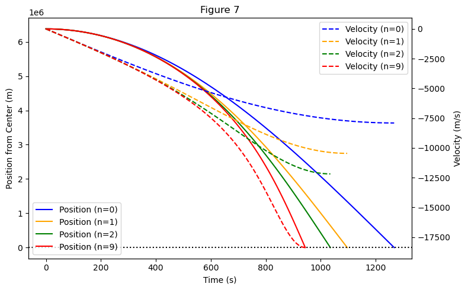

```python
fig7, ax1 = plt.subplots(figsize=(8, 5))
ax2 = ax1.twinx()
colors = ['blue', 'orange', 'green', 'red']

for i, n in enumerate(n_values):
    def non_uniform_fall(t, Y):
        y, v = Y
        if y <= 0.1: # prevent division by zero error at the center
            dv_dt = 0.0
        else:
            unnorm_mass, _ = quad(mass_integrand, 0, y, args=(n,))
            mass_enclosed = rho_n_dict[n] * unnorm_mass
            dv_dt = -G * mass_enclosed / (y**2)
        return [v, dv_dt]

    def reach_center(t, Y):
        return Y[0]

    reach_center.terminal = True

    t_span = (0, 3000)
    Y0 = [R_earth, 0.0]

    # max_step=10 is to force the solver to take "careful" steps
    sol = solve_ivp(non_uniform_fall, t_span, Y0, events=reach_center, max_step=10)

    ax1.plot(sol.t, sol.y[0], linestyle='-', color=colors[i], label=f'Position (n={n})')
    ax2.plot(sol.t, sol.y[1], linestyle='--', color=colors[i], label=f'Velocity (n={n})')

    t_center = sol.t_events[0][0]
    v_center = sol.y_events[0][0][1]
    print(f"n={n}: Time to center = {t_center:.2f} s, Max Speed = {abs(v_center):.2f} m/s")

ax1.set_xlabel("Time (s)")
ax1.set_ylabel("Position from Center (m)", color='black')
ax2.set_ylabel("Velocity (m/s)", color='black')
ax1.axhline(0, color='black', linestyle=':')

ax1.legend(loc='lower left')
ax2.legend(loc='upper right')

plt.title("Figure 7")
plt.tight_layout()
```

## Part 6: A Lunar Mine Shaft

Finally, with all of the framework in place, consider the case where the the mine shaft is instead dug on the moon.

1. Compute the travel time to the center of the moon in case we dig a pole-to-pole mine shaft, so that we can again avoid the Coriolis force, though on the moon this force is very small. No drag force either, which is actually realistic for the moon!
2. What is the density (if you asssume a constant density) of the moon compared to that of earth?
3. How does the fall/orbit time depend on density? See if you can discover a relationship between the density and the fall time. You should think beyond strictly linear relationships.

This problem can actually be done on paper, and then you can compare the answer with that for the homogenous earth you did in Part 4.

```python
vol_earth = (4/3) * np.pi * (R_earth**3)
vol_moon = (4/3) * np.pi * (R_moon**3)
# densities
rho_earth = M_earth / vol_earth
rho_moon = M_moon / vol_moon

print(f"Earth Uniform Density: {rho_earth:.2f} kg/m^3")
print(f"Moon Uniform Density: {rho_moon:.2f} kg/m^3")

g_moon = G * M_moon / (R_moon**2)  # moon gravity

def moon_mine(t, Y):
    y, v = Y
    dy_dt = v
    dv_dt = -g_moon * (y / R_moon)
    return [dy_dt, dv_dt]

def reach_moon_center(t, Y):
    return Y[0]

reach_moon_center.terminal = True

t_span = (0, 4000)
Y0 = [R_moon, 0.0]

sol_moon = solve_ivp(moon_mine, t_span, Y0, events=reach_moon_center)

t_center_moon = sol_moon.t_events[0][0]
v_center_moon = sol_moon.y_events[0][0][1]

print(f"Time to reach Moon's center: {t_center_moon:.2f} s")
print(f"Speed at Moon's center: {abs(v_center_moon):.2f} m/s")

# if t is proportional to 1/sqrt(rho), then t_moon / t_earth should equal sqrt(rho_earth / rho_moon)
time_ratio = t_center_moon / 1266.47 # 1266.47 is the Earth time from part 4
density_ratio = np.sqrt(rho_earth / rho_moon)

print(f"\nRatio of Fall Times (Moon/Earth): {time_ratio:.4f}")
print(f"Square Root of Density Ratios (Earth/Moon): {density_ratio:.4f}")
print("The ratios match! => Proportional")
```

```
Earth Uniform Density: 5494.87 kg/m^3
Moon Uniform Density: 3341.75 kg/m^3
Time to reach Moon's center: 1624.91 s
Speed at Moon's center: 1679.95 m/s

Ratio of Fall Times (Moon/Earth): 1.2830
Square Root of Density Ratios (Earth/Moon): 1.2823
The ratios match! => Proportional
```

We can discover this relationship algebraically ("on paper").

$$a = -\frac{GM}{r^2}$$ Since $M = \frac{4}{3}\pi r^3 \rho$, the acceleration simplifies to:$$a = -\left(\frac{4}{3}\pi G \rho\right) r$$This is the exact form of Simple Harmonic Motion ($a = -\omega^2 x$), where $\omega^2 = \frac{4}{3}\pi G \rho$. The time to fall to the center is one-quarter of the total period ($T/4$), which depends solely on $\omega$. Because $\omega$ is proportional to $\sqrt{\rho}$, the fall time is strictly dependent on the density, not the total size or mass! **Specifically, the fall time is inversely proportional to the square root of the density ($t \propto \frac{1}{\sqrt{\rho}}$).** Because the Moon is less dense than the Earth, it takes longer to fall through it, even though it is much smaller!

## Part 7: Fourier Transforming Orbits

Take the solutions for n=0 and n=9 of the orbits in Part 5 (the inhomogeneous earth) and Fourier Transform them, to see what frequencies (*1/periods*) are dominant in the power spectra. Comment on what you see.

**Hint:** you could take the orbit from the previous integration in Part 5c, but it is useful to increase the integration time and sampling to get more meaningful smooth enough curves. We discussed this in class.

For an example of a spectral analysis of galactic orbits see https://articles.adsabs.harvard.edu/pdf/1982ApJ...252..308B

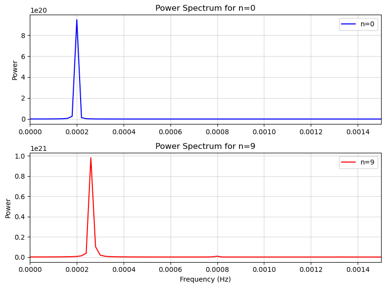

```python
from scipy.fft import rfft, rfftfreq

def mass_integrand(r,n):
    return 4 * np.pi * (r**2) * ((1 - (r / R_earth)**2)**n)

rho_n_dict = {}
for n in [0,9]:
    total_unnorm_mass, _ = quad(mass_integrand, 0, R_earth, args=(n,))
    rho_n_dict[n] = M_earth / total_unnorm_mass

t_max = 50000
dt = 5.0
t_eval = np.arange(0, t_max, dt)
t_span = (0, t_max)
Y0 = [R_earth, 0.0]

# n = 0
def fall_n0(t, Y):
    y, v = Y
    if abs(y) <= 0.1: return [v, 0.0]
    unnorm_mass, _ = quad(mass_integrand, 0, abs(y), args=(0,))
    mass_enclosed = rho_n_dict[0] * unnorm_mass
    # np.sign(y) to ensure force always points to the center
    dv_dt = -np.sign(y) * G * mass_enclosed / (y**2)
    return [v, dv_dt]

# n = 9
def fall_n9(t, Y):
    y, v = Y
    if abs(y) <= 0.1: return [v, 0.0]
    unnorm_mass, _ = quad(mass_integrand, 0, abs(y), args=(9,))
    mass_enclosed = rho_n_dict[9] * unnorm_mass
    dv_dt = -np.sign(y) * G * mass_enclosed / (y**2)
    return [v, dv_dt]

# may take a few seconds
sol_0 = solve_ivp(fall_n0, t_span, Y0, t_eval=t_eval, max_step=10)
sol_9 = solve_ivp(fall_n9, t_span, Y0, t_eval=t_eval, max_step=10)

N = len(t_eval)

yf_0 = rfft(sol_0.y[0])
yf_9 = rfft(sol_9.y[0])
xf = rfftfreq(N, dt)

# power is the magnitude squared of the FFT output
power_0 = np.abs(yf_0)**2
power_9 = np.abs(yf_9)**2

fig, (ax1, ax2) = plt.subplots(2, 1, figsize=(8, 6))

ax1.plot(xf, power_0, color='blue', label='n=0')
ax1.set_xlim(0, 0.0015)
ax1.set_ylabel("Power")
ax1.set_title("Power Spectrum for n=0")
ax1.legend()
ax1.grid(True, alpha=0.5)

ax2.plot(xf, power_9, color='red', label='n=9')
ax2.set_xlim(0, 0.0015)
ax2.set_xlabel("Frequency (Hz)")
ax2.set_ylabel("Power")
ax2.set_title("Power Spectrum for n=9")
ax2.legend()
ax2.grid(True, alpha=0.5)

plt.tight_layout()
```

Describe what we see here:

The power spectrum for $n=0$ features exactly one massive, distinct spike. This is because a perfectly uniform Earth acts exactly like an ideal spring ($F \propto -y$), making the motion a perfect sho. A pure sine wave contains only a single fundamental frequency, which is why there is only one peak.